# Regression for a Categorical Outcome

Machine Learning - Section $3.1.3$

Marc Omar Haddad

Published: 22 February, 2020

**Updated: 23 February, 2020**

The regression approach discussed in previous lessons can also be applied to Categorical Data.

```r
data("heights")
y = heights$height
set.seed(2, sample.kind = "Rounding")

test_index = createDataPartition(y, times = 1, p = 0.5, list = FALSE)
train_set = heights %>% slice(-test_index)
test_set = heights %>% slice(test_index)
```

We will define the outcome as $Y = 1$ for `female`, and $Y = 0$ for `male`, and with feature $X =$`height`. With this definition we are interested in the **Conditional Probability of being `female` when given `height`**; represented mathematically as:
$$\mathrm{Pr}(Y = 1\ |\ X = x)$$

So, we ask ourselves: *What is the **conditional probability of being female** if you are **66 inches** tall?*

```r
train_set %>%
  filter(height == round(66)) %>%
  summarize(`Conditional Prob. of being Female` = mean(sex == "Female"))
```

| Conditional Prob. of being Female |
| --- |
| 0.2142857 |

The Conditional Probability of being `female` given a `height` of $66$ inches is $21.4$%.

Now we will repeat the same exercise for multiple values of $X$.

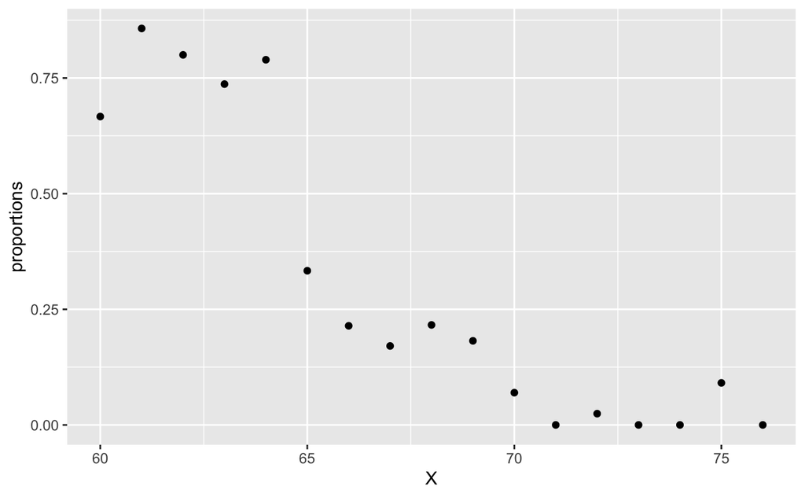

```r
X = seq(60, 76, 1)

proportions = map_dbl(X, function(x) {
  train_set %>%
    filter(height == round(x)) %>%
    summarize(proportion = mean(sex == "Female")) %>%
    .$proportion
})

qplot(X, proportions)
```

Since the results of the above plot appear to be linear, we can try regression.

Reminder: When using regression we assume that **Conditional Probability** can be *expressed* as a **linear function**:
$$p(x) =\ \mathrm{Pr}(Y=1\ |\ X=x)\ = \beta_0 + \beta_1x$$

We plug in our values into the `lm()` function to yield an estimate of $\beta_0$ and $\beta_1$.

```r
lm_fit = mutate(train_set, y = as.numeric(sex == "Female")) %>%
  lm(y ~ height, data = .)
lm_fit$coefficients
```

```
(Intercept)      height
 3.57681946 -0.04907022
```

Now that we have our estimates, we can extract an actual prediction. The estimate of our Conditional Probability is:
$$\hat{p}(x)=\hat{\beta_0} + \hat{\beta_1}x$$

We can visualize our **Conditional Expectations / Conditional Probabilities** by plugging the values of `lm_fit$coefficients` into the above function and plotting the resulting line.

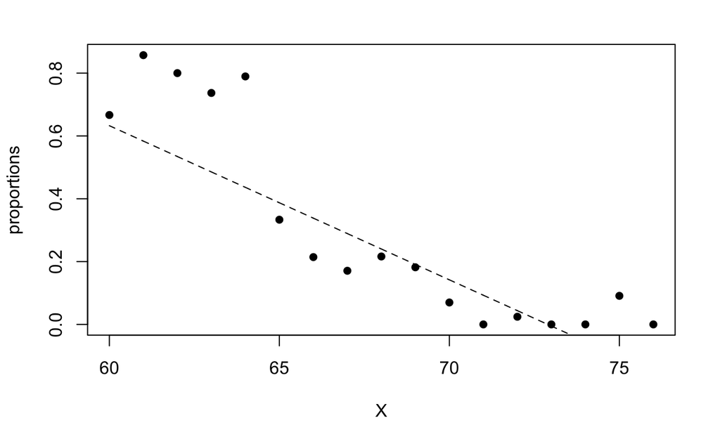

Using this formula, we form a prediction by defining a **Decision Rule**. In this case our Decision Rule is:

**Predict `female` if $\hat{p}(x) > 0.5$**.

We can then use the `confusionMatrix()` function to assess our model.

```r
p_hat = predict(lm_fit, test_set)
y_hat = ifelse(p_hat > 0.5, "Female", "Male") %>% factor()
confusionMatrix(y_hat, test_set$sex)
```

```
Confusion Matrix and Statistics

          Reference
Prediction Female Male
    Female     20   15
    Male       98  393

               Accuracy : 0.7852
                 95% CI : (0.7476, 0.8195)
    No Information Rate : 0.7757
    P-Value [Acc > NIR] : 0.3218

                  Kappa : 0.177

 Mcnemar's Test P-Value : 1.22e-14

            Sensitivity : 0.16949
            Specificity : 0.96324
         Pos Pred Value : 0.57143
         Neg Pred Value : 0.80041
             Prevalence : 0.22433
         Detection Rate : 0.03802
   Detection Prevalence : 0.06654
      Balanced Accuracy : 0.56636

       'Positive' Class : Female
```